# R Markdown - Basico

Oliver Triveño

2025-07-16

## 1. Introducción a R Markdown

### ¿Qué es R Markdown?

R Markdown es un formato de archivo que permite crear documentos dinámicos y reproducibles que combinan texto narrativo con código de R (y otros lenguajes). Con R Markdown, puedes escribir un informe una vez y exportarlo a múltiples formatos de alta calidad, como HTML, PDF, Word, presentaciones y más.

### ¿Por qué usar R Markdown?

- **Reproducibilidad:** Tu análisis es completamente reproducible. Cualquier persona con tu archivo `.Rmd` puede obtener exactamente los mismos resultados.
- **Eficiencia:** Integra tu código, sus resultados (tablas, gráficos) y tus comentarios en un solo lugar. No más copiar y pegar gráficos en un documento de Word.
- **Flexibilidad:** Un único archivo puede generar múltiples tipos de salida.
- **Formato Sencillo:** Utiliza la sintaxis de Markdown, que es muy fácil de aprender.

## 2. La Estructura de un Archivo R Markdown

Un archivo `.Rmd` tiene tres componentes principales:

1. **El encabezado YAML:** Un bloque de configuración al inicio del archivo.
2. **Texto en Markdown:** El texto narrativo que explica tu análisis.
3. **Bloques de código (Code Chunks):** Fragmentos de código de R que se ejecutan para generar resultados.

### 2.1. El Encabezado YAML

El encabezado YAML (YAML Ain´t Markup Language) se encuentra al principio del archivo, delimitado por tres guiones (`---`). Controla las propiedades globales del documento.

### 2.1.1 yaml

```yaml
---
title: "Mi Primer Informe Dinámico"
author: "Oliver Triveño"
date: "15 de julio de 2025"
output: html_document
---
```

- `title`, `author`, `date`: Definen el título, autor y fecha del documento. Puedes usar código R en línea para la fecha, como se muestra en el encabezado de este curso: `2025-07-16`.
- `output`: Especifica el formato de salida. Los más comunes son:
  - `html_document`: Para páginas web interactivas.
  - `pdf_document`: Para documentos PDF (requiere una distribución de LaTeX como `tinytex`).
  - `word_document`: Para documentos de Microsoft Word.

### 2.2. Sintaxis de Markdown

Markdown es una sintaxis simple para formatear texto.

- **Encabezados:** Se crean con `#`. Más `#` significan un nivel de encabezado inferior.
  - `# Nivel 1`
  - `## Nivel 2`
  - `### Nivel 3`
- **Formato de Texto:**
  - *Texto en cursiva* (`*Texto en cursiva*`)
  - **Texto en negrita** (`**Texto en negrita**`)
  - `Código monoespaciado` (`` `Código monoespaciado` ``)
  - Texto tachado (`~~Texto tachado~~`)
- **Listas:**
  - **Desordenada:**
    - Elemento 1
    - Elemento 2
  - **Ordenada:**
    1. Primer punto
    2. Segundo punto
- **Enlaces e Imágenes:**
  - [Visita Google](http://www.google.com)
  - `![Logo de R](https://www.r-project.org/logo/Rlogo.png)`
- **Tablas Simples:**

| Columna 1 | Columna 2 | Columna 3 |
| --- | --- | --- |
| Izquierda | Centrado | Derecha |
| Dato 1 | Dato 2 | Dato 3 |

## 3. Bloques de Código (Code Chunks)

Aquí es donde ocurre la magia. Los bloques de código te permiten ejecutar código R y mostrar los resultados directamente en el documento.

### 3.1. Insertar un Bloque de Código

Para insertar un bloque de código, usa tres comillas invertidas seguidas de `{r}`.

```r
# Esto es un bloque de código de R
# Cargamos la librería ggplot2 para gráficos
library(ggplot2)
```

### 3.2. Opciones del Bloque de Código

Puedes controlar cómo se comporta cada bloque con opciones dentro de las llaves.

- `echo=FALSE`: El código no se mostrará en el documento final, solo su resultado.
- `eval=FALSE`: El código se mostrará, pero no se ejecutará.
- `include=FALSE`: El bloque se ejecuta, pero ni el código ni sus resultados se muestran. (Útil para configuraciones).
- `results='hide'`: Oculta los resultados impresos, pero muestra los gráficos.
- `fig.cap="Título del gráfico"`: Añade un título al gráfico generado.
- `fig.width=8`, `fig.height=5`: Ajusta las dimensiones del gráfico (en pulgadas).

### 3.3. Código en Línea

Puedes insertar valores calculados por R directamente en tu texto. Por ejemplo, el dataset `mtcars` tiene 32 filas. El promedio de millas por galón (mpg) es 20.09.

## 4. Análisis Práctico con el Dataset `iris`

Vamos a realizar un análisis simple del famoso dataset `iris` para demostrar el poder de R Markdown.

### 4.1. Exploración de los Datos

Primero, cargamos los datos y vemos su estructura. El siguiente bloque de código muestra un resumen estadístico del dataset.

```r
# Mostramos las primeras 6 filas del dataset iris
head(iris)
```

| Sepal.Length | Sepal.Width | Petal.Length | Petal.Width | Species |
| --- | --- | --- | --- | --- |
| 5.1 | 3.5 | 1.4 | 0.2 | setosa |
| 4.9 | 3.0 | 1.4 | 0.2 | setosa |
| 4.7 | 3.2 | 1.3 | 0.2 | setosa |
| 4.6 | 3.1 | 1.5 | 0.2 | setosa |
| 5.0 | 3.6 | 1.4 | 0.2 | setosa |
| 5.4 | 3.9 | 1.7 | 0.4 | setosa |

```r
# Usamos summary() para obtener un resumen estadístico de cada variable
summary(iris)
```

```
##   Sepal.Length    Sepal.Width     Petal.Length    Petal.Width
##  Min.   :4.300   Min.   :2.000   Min.   :1.000   Min.   :0.100
##  1st Qu.:5.100   1st Qu.:2.800   1st Qu.:1.600   1st Qu.:0.300
##  Median :5.800   Median :3.000   Median :4.350   Median :1.300
##  Mean   :5.843   Mean   :3.057   Mean   :3.758   Mean   :1.199
##  3rd Qu.:6.400   3rd Qu.:3.300   3rd Qu.:5.100   3rd Qu.:1.800
##  Max.   :7.900   Max.   :4.400   Max.   :6.900   Max.   :2.500
##        Species
##  setosa    :50
##  versicolor:50
##  virginica :50
##
##
##
```

### 4.2. Creando Tablas de Calidad con `knitr::kable()`

Las tablas por defecto son funcionales, pero `knitr::kable()` las hace mucho más profesionales.

```r
# Creamos una tabla más bonita de las primeras 10 filas
knitr::kable(
  head(iris, 10),
  caption = "Primeras 10 observaciones del dataset Iris."
)
```

Primeras 10 observaciones del dataset Iris.

| Sepal.Length | Sepal.Width | Petal.Length | Petal.Width | Species |
| --- | --- | --- | --- | --- |
| 5.1 | 3.5 | 1.4 | 0.2 | setosa |
| 4.9 | 3.0 | 1.4 | 0.2 | setosa |
| 4.7 | 3.2 | 1.3 | 0.2 | setosa |
| 4.6 | 3.1 | 1.5 | 0.2 | setosa |
| 5.0 | 3.6 | 1.4 | 0.2 | setosa |
| 5.4 | 3.9 | 1.7 | 0.4 | setosa |
| 4.6 | 3.4 | 1.4 | 0.3 | setosa |
| 5.0 | 3.4 | 1.5 | 0.2 | setosa |
| 4.4 | 2.9 | 1.4 | 0.2 | setosa |
| 4.9 | 3.1 | 1.5 | 0.1 | setosa |

### 4.3. Visualización de Datos

Una de las mayores ventajas es la capacidad de integrar gráficos directamente en el informe. Aquí, crearemos un gráfico de dispersión para visualizar la relación entre la longitud y la anchura del sépalo, coloreando por especie.

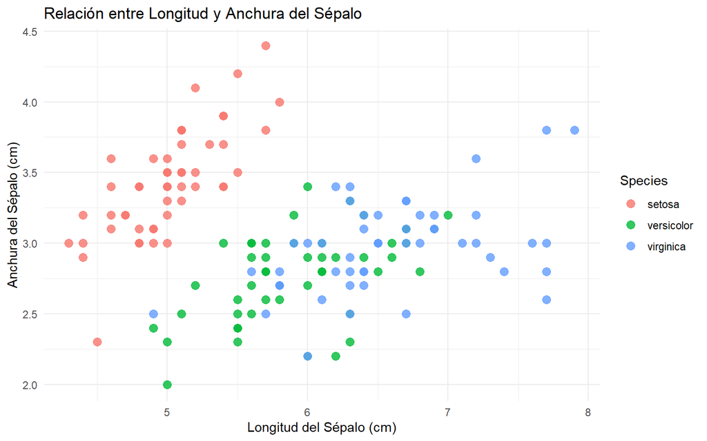

Relación entre Longitud y Anchura del Sépalo en el dataset Iris.

```r
# Creamos el gráfico con ggplot2
ggplot(iris, aes(x = Sepal.Length, y = Sepal.Width, color = Species)) +
  geom_point(size = 3, alpha = 0.8) +
  labs(
    title = "Relación entre Longitud y Anchura del Sépalo",
    x = "Longitud del Sépalo (cm)",
    y = "Anchura del Sépalo (cm)"
  ) +
  theme_minimal()
```

Como podemos observar en la **Figura 1**, la especie *setosa* (en rojo) tiende a tener sépalos más anchos y cortos en comparación con las otras dos especies.

## 5. Ejemplo Avanzado: Análisis del Dataset `mtcars`

Ahora, unificaremos todo lo aprendido en un pequeño proyecto de análisis del dataset `mtcars`.

### 5.1. Pregunta de Investigación

¿Existe una relación entre el peso de un coche (`wt`) y su consumo de combustible (`mpg`)? ¿Cómo influye el número de cilindros (`cyl`) en esta relación?

### 5.2. Manipulación y Resumen de Datos

Usaremos el paquete `dplyr` para agrupar los datos por número de cilindros y calcular estadísticas clave.

```r
library(dplyr)

# Agrupamos por cilindros y calculamos el promedio de mpg y wt
resumen_mtcars <- mtcars %>%
  group_by(cyl) %>%
  summarise(
    promedio_mpg = mean(mpg),
    promedio_wt = mean(wt),
    cantidad = n()
  )

# Mostramos el resultado en una tabla
knitr::kable(
  resumen_mtcars,
  caption = "Resumen de MPG y Peso por Número de Cilindros."
)
```

Resumen de MPG y Peso por Número de Cilindros.

| cyl | promedio_mpg | promedio_wt | cantidad |
| --- | --- | --- | --- |
| 4 | 26.66364 | 2.285727 | 11 |
| 6 | 19.74286 | 3.117143 | 7 |
| 8 | 15.10000 | 3.999214 | 14 |

La tabla anterior muestra claramente que los coches con más cilindros (8) tienen un promedio de millas por galón (MPG) más bajo (15.1) y un peso promedio mayor.

### 5.3. Visualización de la Relación

Finalmente, visualizamos la relación entre el peso y el consumo, facetando por el número de cilindros para responder nuestra pregunta de investigación.

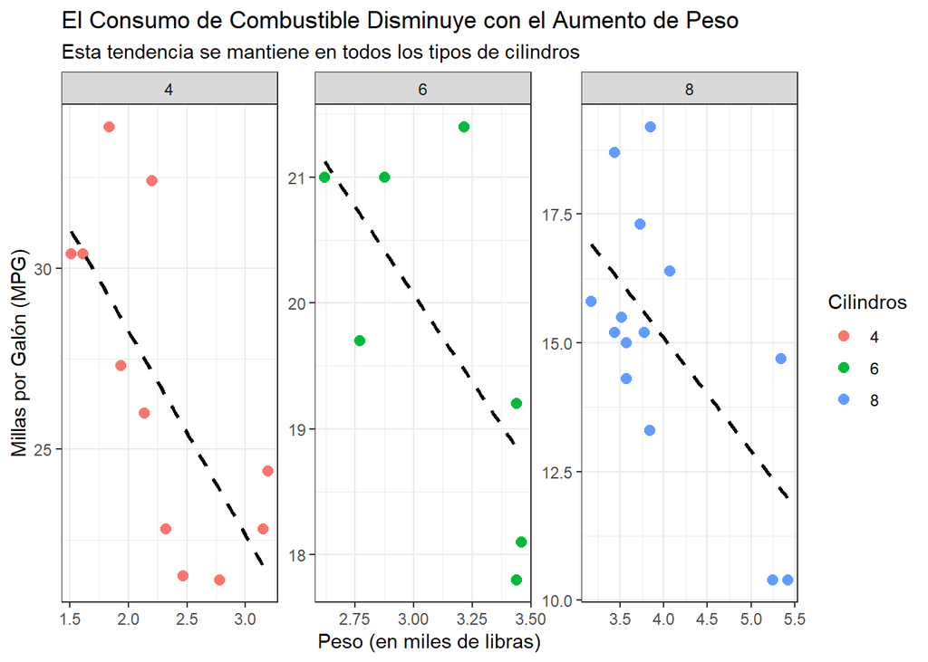

Relación entre Peso y Consumo (MPG), separada por número de cilindros.

```r
ggplot(mtcars, aes(x = wt, y = mpg)) +
  geom_point(aes(color = factor(cyl)), size = 2.5) +
  geom_smooth(method = "lm", se = FALSE, color = "black", linetype = "dashed") +
  facet_wrap(~cyl, scales = "free") +
  labs(
    title = "El Consumo de Combustible Disminuye con el Aumento de Peso",
    subtitle = "Esta tendencia se mantiene en todos los tipos de cilindros",
    x = "Peso (en miles de libras)",
    y = "Millas por Galón (MPG)",
    color = "Cilindros"
  ) +
  theme_bw()
```

### 5.4. Conclusión del Análisis

El análisis confirma una **fuerte relación negativa** entre el peso del vehículo (`wt`) y su eficiencia de combustible (`mpg`). Como se ve en la **Figura 2**, a medida que el peso aumenta, el MPG disminuye. Esta tendencia es consistente en todos los grupos de cilindros, aunque la pendiente de la relación varía.

## 6. Consejos Finales y Próximos Pasos

- **Instala `tinytex`:** Si quieres generar PDFs, ejecuta `install.packages("tinytex")` y luego `tinytex::install_tinytex()` en tu consola de R.
- **Explora otros formatos de salida:** Prueba a cambiar `html_document` por `pdf_document` o `word_document` en el encabezado YAML y vuelve a “Knit”.
- **Documentos interactivos:** Investiga los paquetes `flexdashboard` y `shiny` para crear dashboards y aplicaciones web interactivas directamente desde R Markdown.
- **Bibliografía:** Puedes gestionar citas y bibliografías añadiendo un archivo `.bib` y referenciándolo en el YAML (`bibliography: referencias.bib`).

¡Felicidades! Has completado este curso introductorio a R Markdown. Ahora tienes las herramientas para crear informes elegantes, eficientes y, lo más importante, reproducibles.